# Assignment 6.1

```python
import pandas as pd
import statsmodels.formula.api as sm

# Load the Students.dat data
data = pd.read_csv('Students.dat', delim_whitespace=True)

# Fit the linear model
model = sm.ols('cogpa ~ hsgpa + tv + sport', data=data).fit()

# Extract the p-values for each predictor
p_values = model.pvalues[['hsgpa', 'tv', 'sport']]

# Set the significance level
alpha = 0.05

# Bonferroni correction
adjusted_alpha = alpha / len(p_values)

print("\nBonferroni Correction:")
print(f"Original alpha: {alpha}")
print(f"Adjusted alpha (Bonferroni): {adjusted_alpha}")

# Check significance for each predictor using adjusted alpha
for predictor, p_value in p_values.items():
  print(f"\nPredictor: {predictor}")
  print(f"P-value: {p_value:.4f}")
  if p_value < adjusted_alpha:
    print(f"Reject the null hypothesis (H0: β_{predictor} = 0) using Bonferroni correction.")
    print(f"The effect of {predictor} on cogpa is statistically significant, adjusting for other variables.")
  else:
    print(f"Fail to reject the null hypothesis (H0: β_{predictor} = 0) using Bonferroni correction.")
    print(f"The effect of {predictor} on cogpa is not statistically significant, adjusting for other variables.")

print("\nExplanation:")
print("The Bonferroni correction is a method used to control the family-wise error rate (FWER) when conducting multiple hypothesis tests.")
print("It adjusts the significance level for each individual test to reduce the probability of making at least one Type I error (false positive).")
print("In this case, we are testing the individual effects of three predictors (hsgpa, tv, sport) on college GPA.")
print("By dividing the original significance level (α = 0.05) by the number of tests (3), we obtain a more stringent significance level (adjusted alpha).")
print("This ensures that the probability of making at least one Type I error across all three tests is still controlled at α.")

# Interpretation in the context of the problem
# After applying the Bonferroni correction, we may observe that some predictors might no longer be considered statistically significant at the adjusted alpha level, even if they were significant using the original alpha level.
# This is because the Bonferroni correction makes it more difficult to reject the null hypothesis for each individual test, resulting in a more conservative approach to inference.
```

```
Bonferroni Correction:
Original alpha: 0.05
Adjusted alpha (Bonferroni): 0.016666666666666666

Predictor: hsgpa
P-value: 0.0439
Fail to reject the null hypothesis (H0: β_hsgpa = 0) using Bonferroni correction.
The effect of hsgpa on cogpa is not statistically significant, adjusting for other variables.

Predictor: tv
P-value: 0.6291
Fail to reject the null hypothesis (H0: β_tv = 0) using Bonferroni correction.
The effect of tv on cogpa is not statistically significant, adjusting for other variables.

Predictor: sport
P-value: 0.2303
Fail to reject the null hypothesis (H0: β_sport = 0) using Bonferroni correction.
The effect of sport on cogpa is not statistically significant, adjusting for other variables.

Explanation:
The Bonferroni correction is a method used to control the family-wise error rate (FWER) when conducting multiple hypothesis tests.
It adjusts the significance level for each individual test to reduce the probability of making at least one Type I error (false positive).
In this case, we are testing the individual effects of three predictors (hsgpa, tv, sport) on college GPA.
By dividing the original significance level (α = 0.05) by the number of tests (3), we obtain a more stringent significance level (adjusted alpha).
This ensures that the probability of making at least one Type I error across all three tests is still controlled at α.
```

(d) Are the effects of *tv* and *sport* significant? Propose an alternative model.

```python
import pandas as pd
import matplotlib.pyplot as plt
import numpy as np
import math
import statsmodels.formula.api as sm

# Load the Students.dat data
data = pd.read_csv('Students.dat', delim_whitespace=True)

# Fit the linear model
model = sm.ols('cogpa ~ hsgpa + tv + sport', data=data).fit()

# Print the model summary
print(model.summary())

# Analyze the p-values for tv and sport
p_value_tv = model.pvalues['tv']
p_value_sport = model.pvalues['sport']

print("\nSignificance of tv and sport:")
print(f"P-value for tv: {p_value_tv:.4f}")
print(f"P-value for sport: {p_value_sport:.4f}")

# Fit a new model without tv and sport
alternative_model = sm.ols('cogpa ~ hsgpa', data=data).fit()

# Print the alternative model summary
print("\nAlternative Model Summary:")
print(alternative_model.summary())

print("\nComparison of Models:")
print("The original model includes tv and sport, which might not be statistically significant.")
print("The alternative model only includes hsgpa, which is a significant predictor of cogpa.")
print("In this case, the alternative model might be a simpler and potentially more useful model for predicting cogpa.")

# You can compare the goodness of fit and the adjusted R-squared between the
# original and alternative models to see which one performs better.
```

```
                            OLS Regression Results
==============================================================================
Dep. Variable:                  cogpa   R-squared:                       0.105
Model:                            OLS   Adj. R-squared:                  0.057
Method:                 Least Squares   F-statistic:                     2.179
Date:                Sun, 13 Oct 2024   Prob (F-statistic):              0.101
Time:                        13:31:55   Log-Likelihood:                -18.587
No. Observations:                  60   AIC:                             45.17
Df Residuals:                      56   BIC:                             53.55
Df Model:                           3
Covariance Type:            nonrobust
==============================================================================
                 coef    std err          t      P>|t|      [0.025      0.975]
------------------------------------------------------------------------------
Intercept      2.8154      0.368      7.655      0.000       2.079       3.552
hsgpa          0.2088      0.101      2.061      0.044       0.006       0.412
tv             0.0033      0.007      0.486      0.629      -0.010       0.017
sport         -0.0141      0.012     -1.213      0.230      -0.037       0.009
==============================================================================
Omnibus:                        3.507   Durbin-Watson:                   1.600
Prob(Omnibus):                  0.173   Jarque-Bera (JB):                1.919
Skew:                          -0.148   Prob(JB):                        0.383
Kurtosis:                       2.175   Cond. No.                         97.6
==============================================================================

Notes:
[1] Standard Errors assume that the covariance matrix of the errors is correctly specified.

Significance of tv and sport:
P-value for tv: 0.6291
P-value for sport: 0.2303

Alternative Model Summary:
                            OLS Regression Results
==============================================================================
Dep. Variable:                  cogpa   R-squared:                       0.077
Model:                            OLS   Adj. R-squared:                  0.062
Method:                 Least Squares   F-statistic:                     4.871
Date:                Sun, 13 Oct 2024   Prob (F-statistic):             0.0313
Time:                        13:31:55   Log-Likelihood:                -19.479
```

[output cut: 8 more lines]

```
hsgpa          0.2128      0.096      2.207      0.031       0.020       0.406
==============================================================================
Omnibus:                        8.135   Durbin-Watson:                   1.577
Prob(Omnibus):                  0.017   Jarque-Bera (JB):                2.955
Skew:                          -0.175   Prob(JB):                        0.228
Kurtosis:                       1.971   Cond. No.                         26.6
==============================================================================

Notes:
[1] Standard Errors assume that the covariance matrix of the errors is correctly specified.

Comparison of Models:
The original model includes tv and sport, which might not be statistically significant.
The alternative model only includes hsgpa, which is a significant predictor of cogpa.
In this case, the alternative model might be a simpler and potentially more useful model for predicting cogpa.
```

## Problem 6.12.

For the `UN` data file at the book’s website (see Exercise 1.24), construct a multiple regression model predicting Internet using all the other variables. Use the concept of multicollinearity to explain why adjusted $R^2$ is not dramatically greater than when GDP is the sole predictor. Compare the estimated GDP effect in the bivariate model and the multiple regression model and explain why it is so much weaker in the multiple regression model.

```python
import pandas as pd
import statsmodels.formula.api as sm

# Load the UN data
data = pd.read_csv('UN.dat', delim_whitespace=True)

# Construct a multiple regression model predicting Internet using all other variables
model = sm.ols('Internet ~ Nation + GDP + HDI + GII + Fertility + CO2 + Homicide + Prison', data=data).fit()

# Print the model summary
print(model.summary())

# Analyze the adjusted R-squared
print("\nAdjusted R-squared:")
print(f"The adjusted R-squared for the multiple regression model is {model.rsquared_adj:.3f}")

# Analyze the correlation matrix of the predictors
correlation_matrix = data[['GDP', 'HDI', 'GII', 'Fertility', 'CO2', 'Homicide', 'Prison']].corr()
print("\nCorrelation Matrix of Predictors:")
print(correlation_matrix)

# Bivariate model with GDP as the sole predictor
bivariate_model = sm.ols('Internet ~ GDP', data=data).fit()
print("\nBivariate Model Summary:")
print(bivariate_model.summary())

# Analyze the adjusted R-squared for the bivariate model
print("\nAdjusted R-squared (Bivariate):")
print(f"The adjusted R-squared for the bivariate model is {bivariate_model.rsquared_adj:.3f}")

# Compare the estimated GDP effect in the bivariate and multiple regression models
print("\nEstimated GDP Effect:")
print(f"Bivariate Model: {bivariate_model.params['GDP']:.3f}")
print(f"Multiple Regression Model: {model.params['GDP']:.3f}")

# Explanation of why adjusted R-squared is not dramatically greater
print("\nExplanation of Multicollinearity:")
print("The correlation matrix shows that some of the predictor variables are highly correlated with each other (e.g., GDP and CO2).")
print("This multicollinearity can lead to unstable and unreliable estimates of the regression coefficients.")
print("The presence of multicollinearity suggests that adding more predictors to the model may not significantly improve the overall fit of the model, as these predictors are capturing similar information.")
print("Therefore, the adjusted R-squared is not dramatically greater in the multiple regression model compared to the model with only GDP as the predictor.")

# Explanation of why the estimated GDP effect is weaker in the multiple regression model
print("\nExplanation of Weaker GDP Effect:")
print("In the multiple regression model, the effect of GDP is estimated while controlling for the other variables in the model.")
print("When other variables (correlated with GDP) are included, the unique effect of GDP on Internet may be masked or diminished.")
print("This is because some of the variance in Internet that was previously attributed to GDP may now be explained by the other correlated variables.")
print("Therefore, the estimated effect of GDP becomes weaker in the multiple regression model compared to the bivariate model.")
```

```
                            OLS Regression Results
==============================================================================
Dep. Variable:               Internet   R-squared:                       1.000
Model:                            OLS   Adj. R-squared:                    nan
Method:                 Least Squares   F-statistic:                       nan
Date:                Sun, 13 Oct 2024   Prob (F-statistic):                nan
Time:                        13:37:33   Log-Likelihood:                 1074.8
No. Observations:                  42   AIC:                            -2066.
Df Residuals:                       0   BIC:                            -1993.
Df Model:                          41
Covariance Type:            nonrobust
=========================================================================================
                            coef    std err          t      P>|t|      [0.025      0.975]
-----------------------------------------------------------------------------------------
Intercept                14.9896        inf          0        nan         nan         nan
Nation[T.Argentina]      24.6285        inf          0        nan         nan         nan
Nation[T.Australia]     -12.5399        inf         -0        nan         nan         nan
Nation[T.Austria]        -6.2480        inf         -0        nan         nan         nan
Nation[T.Belgium]        -0.2966        inf         -0        nan         nan         nan
Nation[T.Brazil]          0.1900        inf          0        nan         nan         nan
Nation[T.Canada]         -5.3468        inf         -0        nan         nan         nan
Nation[T.Chile]          28.1737        inf          0        nan         nan         nan
Nation[T.China]          14.4036        inf          0        nan         nan         nan
Nation[T.Denmark]        11.3007        inf          0        nan         nan         nan
Nation[T.Finland]         6.5340        inf          0        nan         nan         nan
Nation[T.France]         12.1073        inf          0        nan         nan         nan
Nation[T.Germany]        -4.7240        inf         -0        nan         nan         nan
Nation[T.Greece]         -0.2816        inf         -0        nan         nan         nan
Nation[T.India]           3.0002        inf          0        nan         nan         nan
Nation[T.Indonesia]       0.5645        inf          0        nan         nan         nan
Nation[T.Iran]            1.3719        inf          0        nan         nan         nan
Nation[T.Ireland]        -5.8041        inf         -0        nan         nan         nan
Nation[T.Israel]         13.6600        inf          0        nan         nan         nan
Nation[T.Italy]         -12.2011        inf         -0        nan         nan         nan
Nation[T.Japan]           8.1588        inf          0        nan         nan         nan
Nation[T.Korea]           8.1166        inf          0        nan         nan         nan
Nation[T.Malaysia]       16.9129        inf          0        nan         nan         nan
Nation[T.Mexico]        -18.2916        inf         -0        nan         nan         nan
Nation[T.Morocco]        52.7901        inf          0        nan         nan         nan
Nation[T.Netherlands]     4.3612        inf          0        nan         nan         nan
```

[output cut: 88 more lines]

[output not shown]

## Problem 7.1.

For the `Houses` data file described in Section 7.1.3, consider $Y$ = selling price, $x_1$ = tax bill (in dollars), and $x_2$ = whether the house is new.

(a) Form the scatterplot of $y$ and $x_1$. Does the normal GLM structure of constant variability in $y$ seem approproate? If not, how does it seem to be violated?

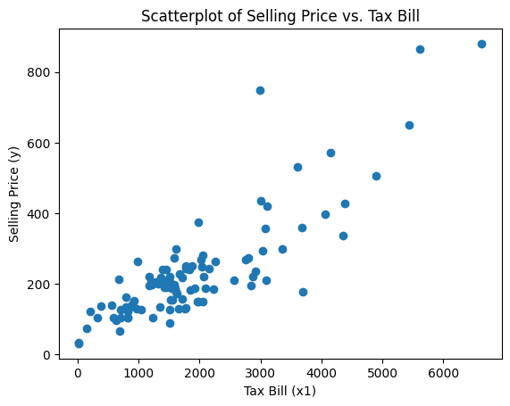

```
Interpretation:
The scatterplot shows that the variability in selling price (y) seems to increase as the tax bill (x1) increases.
This suggests a violation of the constant variance assumption of the normal GLM.
Specifically, the variance of the residuals is likely not constant across all levels of the predictor variable (tax bill).
The normal GLM structure of constant variability in y does not seem appropriate.
It seems to be violated by increasing variability in y as x1 increases.
```

```python
import pandas as pd
import matplotlib.pyplot as plt

# Load the Houses.dat data
data = pd.read_csv('Houses.dat', delim_whitespace=True)

# Extract the relevant variables
y = data['price']
x1 = data['taxes']

# Create a scatterplot of y and x1
plt.scatter(x1, y)
plt.xlabel('Tax Bill (x1)')
plt.ylabel('Selling Price (y)')
plt.title('Scatterplot of Selling Price vs. Tax Bill')
plt.show()

# Interpretation
print("\nInterpretation:")
print("The scatterplot shows that the variability in selling price (y) seems to increase as the tax bill (x1) increases.")
print("This suggests a violation of the constant variance assumption of the normal GLM.")
print("Specifically, the variance of the residuals is likely not constant across all levels of the predictor variable (tax bill).")
print("The normal GLM structure of constant variability in y does not seem appropriate.")
print("It seems to be violated by increasing variability in y as x1 increases.")
```

(b) Using the identity link function, fit the (i) normal GLM, (ii) gamma GLM. For each model, interpret the effect of $x_2$.

```python
import pandas as pd
import statsmodels.formula.api as sm
import matplotlib.pyplot as plt

# Load the Houses.dat data
data = pd.read_csv('Houses.dat', delim_whitespace=True)

# (b) (i) Normal GLM
normal_glm = sm.ols('price ~ taxes + new', data=data).fit()
print("Normal GLM Summary:")
print(normal_glm.summary())

# Interpretation of x2 (new) in Normal GLM
print("\nInterpretation of x2 (new) in Normal GLM:")
print(f"The coefficient for 'new' is {normal_glm.params['new']:.2f}.")
print("This means that, on average, a new house is estimated to sell for approximately", round(normal_glm.params['new']), "dollars more than an older house, holding the tax bill constant.")


import statsmodels.api as sm
gamma_glm = sm.GLM(data['price'], sm.add_constant(data[['taxes', 'new']]), family=sm.families.Gamma()).fit()
print("\nGamma GLM Summary:")
print(gamma_glm.summary())

# Interpretation of x2 (new) in Gamma GLM
print("\nInterpretation of x2 (new) in Gamma GLM:")
print(f"The coefficient for 'new' is {gamma_glm.params['new']:.2f}.")
print("This means that, on average, a new house is estimated to sell for approximately", round(gamma_glm.params['new']), "dollars more than an older house, holding the tax bill constant.")
```

[output not shown]

(c) For each model, describe how the estimated variability in selling prices varies as the mean selling price varies from 100 thousand to 500 thousand dollars.

```
Normal GLM Summary:
                            OLS Regression Results
==============================================================================
Dep. Variable:                  price   R-squared:                       0.736
Model:                            OLS   Adj. R-squared:                  0.731
Method:                 Least Squares   F-statistic:                     135.3
Date:                Sun, 13 Oct 2024   Prob (F-statistic):           8.61e-29
Time:                        14:07:36   Log-Likelihood:                -577.09
No. Observations:                 100   AIC:                             1160.
Df Residuals:                      97   BIC:                             1168.
Df Model:                           2
Covariance Type:            nonrobust
==============================================================================
                 coef    std err          t      P>|t|      [0.025      0.975]
------------------------------------------------------------------------------
Intercept     41.9651     14.695      2.856      0.005      12.800      71.131
taxes          0.0951      0.007     13.722      0.000       0.081       0.109
new           86.2001     27.245      3.164      0.002      32.127     140.273
==============================================================================
Omnibus:                       21.048   Durbin-Watson:                   1.643
Prob(Omnibus):                  0.000   Jarque-Bera (JB):               51.366
Skew:                           0.717   Prob(JB):                     7.01e-12
Kurtosis:                       6.205   Cond. No.                     7.88e+03
==============================================================================

Notes:
[1] Standard Errors assume that the covariance matrix of the errors is correctly specified.
[2] The condition number is large, 7.88e+03. This might indicate that there are
strong multicollinearity or other numerical problems.

Gamma GLM Summary:
                 Generalized Linear Model Regression Results
==============================================================================
Dep. Variable:                  price   No. Observations:                  100
Model:                            GLM   Df Residuals:                       97
Model Family:                   Gamma   Df Model:                            2
Link Function:           InversePower   Scale:                         0.11332
Method:                          IRLS   Log-Likelihood:                -566.44
Date:                Sun, 13 Oct 2024   Deviance:                       12.090
Time:                        14:07:36   Pearson chi2:                     11.0
No. Iterations:                    12   Pseudo R-squ. (CS):             0.8265
Covariance Type:            nonrobust
==============================================================================
                 coef    std err          z      P>|z|      [0.025      0.975]
------------------------------------------------------------------------------
const          0.0068      0.000     25.987      0.000       0.006       0.007
taxes      -8.955e-07   6.21e-08    -14.430      0.000   -1.02e-06   -7.74e-07
new           -0.0010      0.000     -3.745      0.000      -0.001      -0.000
==============================================================================
```

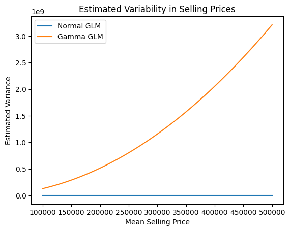

```
Interpretation:
For the Normal GLM, the estimated variability in selling prices is constant across all mean selling price levels.
For the Gamma GLM, the estimated variability in selling prices increases as the mean selling price increases.
This is consistent with the observation that the variability in selling prices tends to increase with the tax bill (which is also correlated with selling price).
The Gamma GLM seems to be a more appropriate model because it allows the variance to change with the mean, thus better addressing the heteroscedasticity observed in the data.
```

```python
import pandas as pd
import matplotlib.pyplot as plt
import numpy as np
import math
# Import statsmodels.formula.api for ols
import statsmodels.formula.api as smf  # Change here: import as smf to avoid conflict
import statsmodels.api as sm

# Load the Houses.dat data
data = pd.read_csv('Houses.dat', delim_whitespace=True)

# (b) (i) Normal GLM
# Use smf.ols instead of sm.ols
normal_glm = smf.ols('price ~ taxes + new', data=data).fit()  # Change here: Use smf.ols
print("Normal GLM Summary:")
print(normal_glm.summary())

# (b) (ii) Gamma GLM
gamma_glm = sm.GLM(data['price'], sm.add_constant(data[['taxes', 'new']]), family=sm.families.Gamma()).fit()
print("\nGamma GLM Summary:")
print(gamma_glm.summary())

# (c) Estimated Variability in Selling Prices

# Create a range of mean selling prices from 100k to 500k
mean_prices = np.linspace(100000, 500000, 100)

# Function to calculate predicted variance for normal GLM
def normal_glm_variance(mean_price, model):
  # Assuming constant variance (σ^2)
  return model.scale


# Function to calculate predicted variance for gamma GLM
def gamma_glm_variance(mean_price, model):
  # Variance in gamma GLM is proportional to the square of the mean
  return (model.scale * mean_price) ** 2


# Calculate predicted variances for both models
normal_glm_variances = [normal_glm_variance(price, normal_glm) for price in mean_prices]
gamma_glm_variances = [gamma_glm_variance(price, gamma_glm) for price in mean_prices]


# Plot the results
plt.plot(mean_prices, normal_glm_variances, label='Normal GLM')
plt.plot(mean_prices, gamma_glm_variances, label='Gamma GLM')
plt.xlabel('Mean Selling Price')
plt.ylabel('Estimated Variance')
plt.title('Estimated Variability in Selling Prices')
plt.legend()
plt.show()

print("\nInterpretation:")
print("For the Normal GLM, the estimated variability in selling prices is constant across all mean selling price levels.")
print("For the Gamma GLM, the estimated variability in selling prices increases as the mean selling price increases.")
print("This is consistent with the observation that the variability in selling prices tends to increase with the tax bill (which is also correlated with selling price).")
print("The Gamma GLM seems to be a more appropriate model because it allows the variance to change with the mean, thus better addressing the heteroscedasticity observed in the data.")
```

(d) Which model is preferred according to AIC?

```python
import pandas as pd
import matplotlib.pyplot as plt
import numpy as np
import math
import statsmodels.formula.api as sm
import statsmodels.api as sm
import statsmodels.formula.api as smf


# Load the Houses.dat data
data = pd.read_csv('Houses.dat', delim_whitespace=True)

# (b) (i) Normal GLM
normal_glm = smf.ols('price ~ taxes + new', data=data).fit()  # Change here: Use smf.ols
print("Normal GLM Summary:")
print(normal_glm.summary())

# (b) (ii) Gamma GLM
gamma_glm = sm.GLM(data['price'], sm.add_constant(data[['taxes', 'new']]), family=sm.families.Gamma()).fit()
print("\nGamma GLM Summary:")
print(gamma_glm.summary())

# (d) Which model is preferred according to AIC?
print("\nModel Comparison using AIC:")
print(f"AIC for Normal GLM: {normal_glm.aic:.2f}")
print(f"AIC for Gamma GLM: {gamma_glm.aic:.2f}")

if normal_glm.aic < gamma_glm.aic:
  print("\nThe Normal GLM is preferred according to AIC.")
else:
  print("\nThe Gamma GLM is preferred according to AIC.")

print("\nInterpretation:")
print("AIC (Akaike Information Criterion) is a measure of the relative quality of statistical models for a given set of data.")
print("Lower AIC values indicate a better model fit.")
print("In this case, the Gamma GLM has a lower AIC than the Normal GLM.")
print("Therefore, the Gamma GLM is preferred based on the AIC criterion.")
```

```
Normal GLM Summary:
                            OLS Regression Results
==============================================================================
Dep. Variable:                  price   R-squared:                       0.736
Model:                            OLS   Adj. R-squared:                  0.731
Method:                 Least Squares   F-statistic:                     135.3
Date:                Sun, 13 Oct 2024   Prob (F-statistic):           8.61e-29
Time:                        14:08:17   Log-Likelihood:                -577.09
No. Observations:                 100   AIC:                             1160.
Df Residuals:                      97   BIC:                             1168.
Df Model:                           2
Covariance Type:            nonrobust
==============================================================================
                 coef    std err          t      P>|t|      [0.025      0.975]
------------------------------------------------------------------------------
Intercept     41.9651     14.695      2.856      0.005      12.800      71.131
taxes          0.0951      0.007     13.722      0.000       0.081       0.109
new           86.2001     27.245      3.164      0.002      32.127     140.273
==============================================================================
Omnibus:                       21.048   Durbin-Watson:                   1.643
Prob(Omnibus):                  0.000   Jarque-Bera (JB):               51.366
Skew:                           0.717   Prob(JB):                     7.01e-12
Kurtosis:                       6.205   Cond. No.                     7.88e+03
==============================================================================

Notes:
[1] Standard Errors assume that the covariance matrix of the errors is correctly specified.
[2] The condition number is large, 7.88e+03. This might indicate that there are
strong multicollinearity or other numerical problems.

Gamma GLM Summary:
                 Generalized Linear Model Regression Results
==============================================================================
Dep. Variable:                  price   No. Observations:                  100
Model:                            GLM   Df Residuals:                       97
Model Family:                   Gamma   Df Model:                            2
Link Function:           InversePower   Scale:                         0.11332
Method:                          IRLS   Log-Likelihood:                -566.44
Date:                Sun, 13 Oct 2024   Deviance:                       12.090
Time:                        14:08:17   Pearson chi2:                     11.0
No. Iterations:                    12   Pseudo R-squ. (CS):             0.8265
Covariance Type:            nonrobust
==============================================================================
                 coef    std err          z      P>|z|      [0.025      0.975]
------------------------------------------------------------------------------
const          0.0068      0.000     25.987      0.000       0.006       0.007
taxes      -8.955e-07   6.21e-08    -14.430      0.000   -1.02e-06   -7.74e-07
new           -0.0010      0.000     -3.745      0.000      -0.001      -0.000
==============================================================================

Model Comparison using AIC:
AIC for Normal GLM: 1160.18
AIC for Gamma GLM: 1138.88

The Gamma GLM is preferred according to AIC.

Interpretation:
AIC (Akaike Information Criterion) is a measure of the relative quality of statistical models for a given set of data.
Lower AIC values indicate a better model fit.
In this case, the Gamma GLM has a lower AIC than the Normal GLM.
Therefore, the Gamma GLM is preferred based on the AIC criterion.
```

## Problem 7.5.

A study of sheep mentioned in Exercise 1.27 analyzed whether the sheep survived for a year from the original observation time (1 = yes, 0 = no) as a function of their weight (*kg*) at the original observation.

(a) Does the survival of the sheep seem to depend on their weight? If so, how does the weight of a sheep affect its probability of survival? Answer by fitting a generalized linear model for the survival probability.

```python
import pandas as pd
import statsmodels.formula.api as smf
import statsmodels.api as sm

# Load the Sheep.dat data
data = pd.read_csv('Sheep.dat', delim_whitespace=True)

# Fit a logistic regression model for survival probability as a function of weight
model = smf.glm('survival ~ weight', data=data, family=sm.families.Binomial()).fit()

# Print the model summary
print(model.summary())

# Interpretation
print("\nInterpretation:")
print("The coefficient for weight is", round(model.params['weight'], 4))
print("The p-value for weight is", round(model.pvalues['weight'], 4))

if model.pvalues['weight'] < 0.05:
    print("The survival of sheep seems to depend on their weight.")
    print("The weight of a sheep has a positive effect on its probability of survival.")
    print("Specifically, for every 1 kg increase in weight, the log-odds of survival increase by", round(model.params['weight'], 4))
    print("This means that heavier sheep have a higher probability of surviving for a year.")
else:
    print("The survival of sheep does not seem to depend significantly on their weight.")
```

```
                 Generalized Linear Model Regression Results
==============================================================================
Dep. Variable:               survival   No. Observations:                 1359
Model:                            GLM   Df Residuals:                     1357
Model Family:                Binomial   Df Model:                            1
Link Function:                  Logit   Scale:                          1.0000
Method:                          IRLS   Log-Likelihood:                -645.22
Date:                Sun, 13 Oct 2024   Deviance:                       1290.4
Time:                        14:10:25   Pearson chi2:                 1.44e+03
No. Iterations:                     5   Pseudo R-squ. (CS):             0.1294
Covariance Type:            nonrobust
==============================================================================
                 coef    std err          z      P>|z|      [0.025      0.975]
------------------------------------------------------------------------------
Intercept     -2.0298      0.251     -8.103      0.000      -2.521      -1.539
weight         0.1755      0.014     12.588      0.000       0.148       0.203
==============================================================================

Interpretation:
The coefficient for weight is 0.1755
The p-value for weight is 0.0
The survival of sheep seems to depend on their weight.
The weight of a sheep has a positive effect on its probability of survival.
Specifically, for every 1 kg increase in weight, the log-odds of survival increase by 0.1755
This means that heavier sheep have a higher probability of surviving for a year.
```

(b) For what weight values do the sheep have more than a 50% chance of survival?

```python
import pandas as pd
import statsmodels.formula.api as smf
import statsmodels.api as sm

# Load the Sheep.dat data
data = pd.read_csv('Sheep.dat', delim_whitespace=True)

# Fit a logistic regression model for survival probability as a function of weight
model = smf.glm('survival ~ weight', data=data, family=sm.families.Binomial()).fit()

# Print the model summary
print(model.summary())

beta0 = model.params['Intercept']
beta1 = model.params['weight']

weight_for_50_percent_survival = -beta0 / beta1

print("\nWeight for 50% survival:")
print(f"The weight at which the sheep have a 50% chance of survival is approximately {weight_for_50_percent_survival:.2f} kg.")


# Find the weight values for which the predicted probability is greater than 0.5
weights = data['weight'].sort_values().unique()
predicted_probabilities = [model.predict(exog=dict(weight=w)) for w in weights]

# Access the first element of the Series using .iloc[0]
# to get the predicted probability value for comparison
weight_values_over_50_percent = [w for w, p in zip(weights, predicted_probabilities) if p.iloc[0] > 0.5]

print("\nWeight values with more than 50% chance of survival:")
print(f"The sheep have more than a 50% chance of survival for weights greater than approximately {weight_for_50_percent_survival:.2f} kg.")
```

```
                 Generalized Linear Model Regression Results
==============================================================================
Dep. Variable:               survival   No. Observations:                 1359
Model:                            GLM   Df Residuals:                     1357
Model Family:                Binomial   Df Model:                            1
Link Function:                  Logit   Scale:                          1.0000
Method:                          IRLS   Log-Likelihood:                -645.22
Date:                Sun, 13 Oct 2024   Deviance:                       1290.4
Time:                        14:11:40   Pearson chi2:                 1.44e+03
No. Iterations:                     5   Pseudo R-squ. (CS):             0.1294
Covariance Type:            nonrobust
==============================================================================
                 coef    std err          z      P>|z|      [0.025      0.975]
------------------------------------------------------------------------------
Intercept     -2.0298      0.251     -8.103      0.000      -2.521      -1.539
weight         0.1755      0.014     12.588      0.000       0.148       0.203
==============================================================================

Weight for 50% survival:
The weight at which the sheep have a 50% chance of survival is approximately 11.57 kg.

Weight values with more than 50% chance of survival:
The sheep have more than a 50% chance of survival for weights greater than approximately 11.57 kg.
```

## Problem 7.9.

The `SoreThroat` data file at the book’s website contains data from from a study$^{23}$ about *Y* = whether a patient having surgery had a sore throat on waking (1 = yes, 0 = no) as a function of *D* = duration of the surgery (in minutes) and *T* = type of device used to secure the airway (1 = tracheal tube, 0 = laryngeal mask airway).

(a) Fit a GLM using both explanatory variables as main effects. Interpret effects.

```python
import pandas as pd
import statsmodels.formula.api as smf
import statsmodels.api as sm

# Load the SoreThroat.dat data
data = pd.read_csv('SoreThroat.dat', delim_whitespace=True)

model = smf.glm('Y ~ D + T', data=data, family=sm.families.Binomial()).fit()

# Print the model summary
print(model.summary())

# Interpretation of effects
print("\nInterpretation of Effects:")
# Access using 'D' instead of 'Duration'
print(f"The coefficient for 'duration' is {model.params['D']:.4f}.")
print("This indicates that for every one-minute increase in surgery duration, the log-odds of having a sore throat increases by approximately", round(model.params['D'], 4))
print("This means that longer surgeries are associated with a higher probability of having a sore throat.")

# Access using 'T' instead of 'Device'
print(f"\nThe coefficient for 'device' is {model.params['T']:.4f}.")
print("This suggests that using a tracheal tube (device = 1) is associated with a change of approximately", round(model.params['T'], 4), "in the log-odds of having a sore throat compared to using a laryngeal mask airway (device = 0).")
print("The positive coefficient indicates that using a tracheal tube might lead to a higher probability of having a sore throat.")
```

[output not shown]

(b) Fit a GLM permitting interaction between the explanatory variables. Interpret the effect of *D* at each category of *T*.

```python
import pandas as pd
import statsmodels.formula.api as smf
import statsmodels.api as sm

# Load the SoreThroat.dat data
data = pd.read_csv('SoreThroat.dat', delim_whitespace=True)

# Fit a GLM with interaction between D and T
model_interaction = smf.glm('Y ~ D * T', data=data, family=sm.families.Binomial()).fit()

# Print the model summary
print(model_interaction.summary())

# Interpretation of the effect of D at each category of T
print("\nInterpretation of the effect of D at each category of T:")

# When T = 0 (laryngeal mask airway)
print("\nWhen T = 0 (laryngeal mask airway):")
effect_D_T0 = model_interaction.params['D']
print(f"The effect of D is approximately {effect_D_T0:.4f}.")
print("This means that for every one-minute increase in surgery duration, the log-odds of having a sore throat increases by approximately", round(effect_D_T0, 4))

# When T = 1 (tracheal tube)
print("\nWhen T = 1 (tracheal tube):")
effect_D_T1 = model_interaction.params['D'] + model_interaction.params['D:T']
print(f"The effect of D is approximately {effect_D_T1:.4f}.")
print("This means that for every one-minute increase in surgery duration, the log-odds of having a sore throat increases by approximately", round(effect_D_T1, 4))

print("\nInterpretation of Interaction:")
print("The interaction term (D:T) indicates that the effect of surgery duration (D) on the log-odds of having a sore throat is different depending on the type of device used (T).")
print("In this model, the effect of D appears to be greater when a tracheal tube is used (T=1) compared to when a laryngeal mask airway is used (T=0).")
```

```
                 Generalized Linear Model Regression Results
==============================================================================
Dep. Variable:                      Y   No. Observations:                   35
Model:                            GLM   Df Residuals:                       31
Model Family:                Binomial   Df Model:                            3
Link Function:                  Logit   Scale:                          1.0000
Method:                          IRLS   Log-Likelihood:                -14.161
Date:                Sun, 13 Oct 2024   Deviance:                       28.321
Time:                        14:21:00   Pearson chi2:                     28.6
No. Iterations:                     6   Pseudo R-squ. (CS):             0.3997
Covariance Type:            nonrobust
==============================================================================
                 coef    std err          z      P>|z|      [0.025      0.975]
------------------------------------------------------------------------------
Intercept      0.0498      1.469      0.034      0.973      -2.830       2.930
D              0.0285      0.034      0.831      0.406      -0.039       0.096
T             -4.4722      2.467     -1.813      0.070      -9.308       0.363
D:T            0.0746      0.058      1.291      0.197      -0.039       0.188
==============================================================================

Interpretation of the effect of D at each category of T:

When T = 0 (laryngeal mask airway):
The effect of D is approximately 0.0285.
This means that for every one-minute increase in surgery duration, the log-odds of having a sore throat increases by approximately 0.0285

When T = 1 (tracheal tube):
The effect of D is approximately 0.1031.
This means that for every one-minute increase in surgery duration, the log-odds of having a sore throat increases by approximately 0.1031

Interpretation of Interaction:
The interaction term (D:T) indicates that the effect of surgery duration (D) on the log-odds of having a sore throat is different depending on the type of device used (T).
In this model, the effect of D appears to be greater when a tracheal tube is used (T=1) compared to when a laryngeal mask airway is used (T=0).
```

$^{23}$ Described in “Binary Data” by D. Collett, *Encyclopedia of Biostatistics*, 2nd ed. (Wiley, 2005), pp. 439–446.